# 2nd Chance Survey: Final Report

Sabina Rodriguez

19 November, 2026

# Report Purpose

This report presents preliminary descriptive findings from the 2nd Chance Survey, examining the demographic characteristics, professional training, geographic distribution, and clinical practice settings of plastic and reconstructive surgeons currently practicing in Sub-Saharan Africa (SSA). The analysis characterizes the surveyed workforce and identifies patterns in professional backgrounds, institutional affiliations, and geographic distribution that may inform further research and workforce planning in the region.

Findings reflect the participating respondents and the facilities they reported and should not be interpreted as representative of the entire plastic and reconstructive surgery workforce in SSA.

# Introduction

## Background

Access to plastic and reconstructive surgery (PRS) remains limited across Sub-Saharan Africa (SSA), despite a substantial burden of trauma, burns, and congenital malformations. Limited specialist availability, uneven workforce distribution, and resource constraints further restrict access to essential reconstructive services. Although surgical workforce assessments have been conducted across the region, comprehensive data on the distribution, practice characteristics, and facility capacity of PRS specialists remain scarce. This information is essential to identify service gaps and inform workforce development and surgical system strengthening.

## Objective

This study aimed to assess the geographic distribution, workforce density, and service delivery capacity of accredited plastic and reconstructive surgeons across SSA. Specifically, it sought to characterize surgeons’ practice settings, surgical workload, and the availability of infrastructure, equipment, supplies, and training resources at participating facilities. Methodology

A cross-sectional, multi-country survey was designed to assess PRS workforce and facility capacity across SSA, particularly in countries affiliated with the College of Surgeons of East, Central and Southern Africa (COSECSA) and the West African College of Surgeons (WACS).

A purposive census sampling approach, supplemented by snowball sampling, was used to identify eligible accredited plastic and reconstructive surgeons through professional associations, training institutions, hospitals, and professional networks. Data were collected electronically using a structured questionnaire administered through KoboToolbox. The survey assessed demographic and professional characteristics, geographic distribution, practice settings, surgical workload, facility resources, and training capacity.

Survey responses were de-identified and prepared for analysis using R. Descriptive statistics were used to summarize workforce characteristics and facility capacity. Geographic mapping was used to assess workforce distribution, and surgeon density was calculated per 100,000 population using publicly available population estimates.

## Ethical Considerations

Ethical approval was obtained from the BASEC and CUREG ethics review bodies in Switzerland and the College of Surgeons of East, Central and Southern Africa (COSECSA) Institutional Review Board (IRB) prior to study commencement. Participation was voluntary, and electronic informed consent was obtained before survey completion. The study collected no patient-level information. All survey responses were de-identified and securely stored, with access restricted to authorized research personnel. Findings were reported in aggregate to protect participant and institutional confidentiality.

# Response Rate and Data Completeness

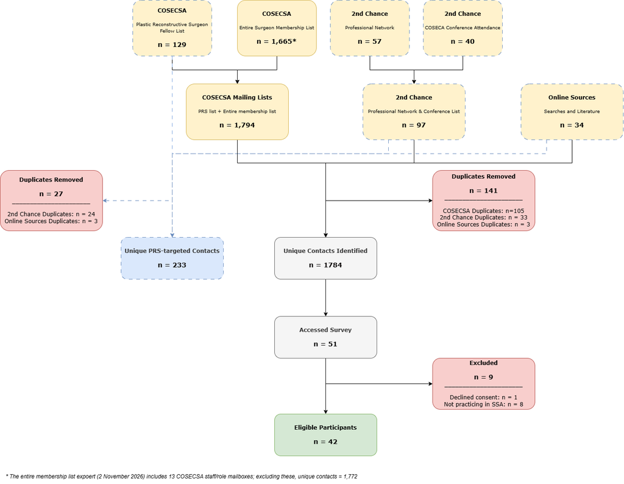

Figure 1. Participant identification and inclusion flowdiagram. Numbers highlighted in red are to be confirmed with COSECSA

During data cleaning, one respondent aged 50–59 years reported a specialty accreditation year of 1950, implying 76 years since accreditation — inconsistent with the reported age and not reliably correctable. Both the accreditation year and the derived years-in-practice variable were treated as missing for this individual, who was retained in all other analyses for which valid data were available.

Analyses involving accreditation year therefore have a denominator of N = 41.

# Respondent Characteristics

## Age and Gender

The demographic composition of survey respondents was examined according to age group and gender. Together, these characteristics provide an overview of the age and gender representation within the participating surgical workforce.

### Participant Characteristics

Table 1 summarizes respondents’ demographic characteristics and countries of practice. Age, gender, and geographic distributions are reported as frequencies and percentages, with denominators based on available responses for each characteristic.

Participant Characteristics

N = 42 respondents

| Surgeons (age groups), n (%) | N = 42 respondents |
| --- | --- |
| 30-39 | 25 (59.5%) |
| 40-49 | 6 (14.3%) |
| 50-59 | 5 (11.9%) |
| <30 | 4 (9.5%) |
| >59 | 2 (4.8%) |
| Surgeons by gender, n (%) | N = 42 respondents |
| Male | 28 (66.7%) |
| Female | 14 (33.3%) |
| Country of Practice, n (%) | N = 42 respondents |
| Ethiopia | 14 (33.3%) |
| Rwanda | 9 (21.4%) |
| Kenya | 4 (9.5%) |
| Uganda | 4 (9.5%) |
| Democratic Republic of the Congo | 2 (4.8%) |
| Nigeria | 2 (4.8%) |
| Tanzania | 2 (4.8%) |
| Burundi | 1 (2.4%) |
| Côte d'Ivoire | 1 (2.4%) |
| Malawi | 1 (2.4%) |
| Somalia | 1 (2.4%) |
| Togo | 1 (2.4%) |

### Age and Gender Distribution

The combined age and gender distribution is presented in Figure 3. This analysis examines how age groups are represented among male and female respondents, providing additional insight into the demographic composition of participating surgeons.

[interactive chart not shown]

## Country of Practice

The table below summarizes the geographic distribution of reported countries of practice among respondents, including the frequency and percentage of each country. As respondents could practice in multiple countries, percentages are based on the total number of country mentions.

[interactive chart not shown]

The geographic distribution of reported practice locations was concentrated in East Africa, with Ethiopia and Rwanda alone accounting for 51.2% of all country mentions. Because respondents could report practicing in more than one country, these percentages represent the distribution of reported practice locations rather than the proportion of unique respondents. This concentration may reflect the geographic reach of survey recruitment networks, particularly COSECSA, and should not be interpreted as representative of the overall distribution of plastic surgeons or surgical capacity across SSA.

# Professional Training

Professional training characteristics were examined to describe the educational qualifications, accreditation pathways, years since specialty accreditation, and current professional positions of participating surgeons.

## Years Since Specialty Accreditation

[interactive chart not shown]

The vast majority of respondents — 30 of 41 with valid accreditation data (73.2%) — received specialty accreditation in 2020 or later, confirming the early-career profile of the sample. A further 5 respondents (12.2%) were accredited between 2010 and 2019, and 6 (14.6%) between 2000 and 2009. No respondents reported accreditation before 2000 (the one anomalous 1950 value was excluded as described in the data completeness section).

## Professional Training Background

Table 2 summarizes professional qualifications, accreditation bodies, and periods of specialty accreditation among respondents. These findings characterize the training backgrounds and accreditation histories represented within the surveyed workforce.

**Professional Training Background**

Total sample: N = 42

| Characteristic | N | % |
| --- | --- | --- |
| Highest Qualification | 42 |  |
| Fellowship | 19 | 45.2 |
| Membership qualification | 12 | 28.6 |
| Master’s degree in Surgery | 7 | 16.7 |
| Doctoral/research degree | 2 | 4.8 |
| Primary medical degree | 2 | 4.8 |
| Primary Accreditation Body | 42 |  |
| COSECSA | 22 | 52.4 |
| National training program | 14 | 33.3 |
| International training program | 3 | 7.1 |
| WACS | 2 | 4.8 |
| Other | 1 | 2.4 |
| Year of Specialty Accreditation | 41 |  |
| 2000-2009 | 6 | 14.6 |
| 2010-2019 | 5 | 12.2 |
| 2020+ | 30 | 73.2 |

## Current Professional Position

Consultant/Attending surgeons were the most common position, comprising 16 respondents (38.1%). Residents and trainees accounted for 15 respondents (35.7%), making trainees collectively the second largest group. Academic faculty and Fellows each accounted for 4 respondents (9.5% each), and Department heads/chairs for 3 (7.1%). Taken together, the high proportion of trainees and early-career consultants (38.1% + 35.7% = 73.8%) reinforces the predominantly junior profile identified in the age and accreditation data.

**Current Professional Position**

Total sample: N = 42

| Professional Position | N | % |
| --- | --- | --- |
| Academic faculty | 4 | 9.5 |
| Department head/chair | 3 | 7.1 |
| Consultant/Attending surgeon | 16 | 38.1 |
| Resident/Trainee | 15 | 35.7 |
| Fellow | 4 | 9.5 |

## Subspecialty

Respondents could select multiple subspecialties. Reported subspecialties spanned the breadth of plastic and reconstructive surgery, including burn surgery, hand surgery, craniofacial and cleft surgery, microsurgery, aesthetic surgery, and general reconstructive surgery, among others. Because respondents could identify with more than one area, percentages are not expected to total 100% and are reported by subspecialty in the accompanying figures.

[interactive chart not shown]

# Practice Settings

Clinical practice settings were examined to characterize the institutions where respondents reported providing surgical services. The analysis considers facility characteristics, institutional ownership, geographic location, and the number of facilities associated with individual surgeons.

Because individual surgeons may practice at multiple institutions and multiple respondents may report the same facility, facility-level and respondent-level findings are presented separately.

## Facilities Reported by Respondents

Respondents collectively identified 52 unique healthcare facilities across 12 countries. The University Teaching Hospital of Kigali (CHUK) was the most frequently reported facility, cited by 8 respondents, followed by ALERT Comprehensive Specialized Hospital in Ethiopia (5 respondents) and Yekatit 12 Hospital Medical College in Ethiopia (4 respondents). Rwanda Military Teaching and Referral Hospital was cited by 3 respondents; AIC Kijabe Hospital (Kenya), AaBET Hospital (Ethiopia), Felege Hiwot Hospital (Ethiopia), Mulago National Referral Hospital (Uganda), and Worabe Comprehensive Specialized Hospital (Ethiopia) were each cited by 2 respondents. The remaining 43 facilities were each cited by a single respondent.

Facility Characteristics

N = 52 facilities

| Urban vs. Rural, n (%) | N = 52 facilities |
| --- | --- |
| Urban | 45 (86.5%) |
| Rural | 7 (13.5%) |
| Level of Health Facility, n (%) | N = 52 facilities |
| Central | 11 (21.2%) |
| Provincial | 11 (21.2%) |
| University | 11 (21.2%) |
| District | 9 (17.3%) |
| Central University | 7 (13.5%) |
| Other | 1 (1.9%) |
| Provincial Central | 1 (1.9%) |
| Provincial University | 1 (1.9%) |
| Facility Ownership Type, n (%) | N = 52 facilities |
| Public | 18 (34.6%) |
| Private | 17 (32.7%) |
| Quasi Gov | 6 (11.5%) |
| NGO | 5 (9.6%) |
| Mission | 3 (5.8%) |
| Military | 2 (3.8%) |
| Other | 1 (1.9%) |

## Facility Characteristics

Reported healthcare facilities differed in geographic setting, institutional level, and ownership structure.

Table 5 summarizes the distribution of unique reported facilities across urban and rural settings, healthcare facility levels, and ownership categories. These characteristics provide context for understanding the institutional environments in which participating surgeons practice.

Facility Characteristics

N = 52 facilities

| Urban vs. Rural, n (%) | N = 52 facilities |
| --- | --- |
| urban | 45 (86.5%) |
| rural | 7 (13.5%) |
| Level of Health Facility, n (%) | N = 52 facilities |
| central | 11 (21.2%) |
| provincial | 11 (21.2%) |
| university | 11 (21.2%) |
| district | 9 (17.3%) |
| central university | 7 (13.5%) |
| other | 1 (1.9%) |
| provincial central | 1 (1.9%) |
| provincial university | 1 (1.9%) |
| Facility Ownership Type, n (%) | N = 52 facilities |
| public | 18 (34.6%) |
| private | 17 (32.7%) |
| quasi_gov | 6 (11.5%) |
| ngo | 5 (9.6%) |
| mission | 3 (5.8%) |
| military | 2 (3.8%) |
| other | 1 (1.9%) |

## Multiple Facilities

Survey respondents reported different patterns of institutional affiliation, including practice at a single facility and practice across multiple facilities.

### Number of Operating Facilities

These results describe the extent to which participating surgeons practice across multiple healthcare institutions and provide additional context for interpreting facility-level reporting within the survey.

Distribution of Number of Facilities

N = 42 respondents

| Number of Servicing Facilities, n (%) | N = 42 facilities |
| --- | --- |
| 1 | 19 (45.2%) |
| 2 | 16 (38.1%) |
| 3 | 5 (11.9%) |
| 4 | 2 (4.8%) |

A proportion of respondents reported practicing at more than one facility. The number of facilities per respondent is detailed in the accompanying figures. Practice across multiple institutions increases the aggregate service reach of individual surgeons but may also reflect fragmented or cross-subsidised service delivery — a pattern worth exploring in subsequent analyses.

# Workforce Profile

## Staffing Numbers per Facility

Reported Surgical Workforce by Facility and Country

Facility-level workforce estimates

| Facility | Respondents (n) | PRS surgeons | PRS trainees | OT nurses | Physiotherapists |
| --- | --- | --- | --- | --- | --- |
| Burundi |  |  |  |  |  |
| Matana Referral Hospital | 1 | 1 | 0 | 1 | 1 |
| Tanganyika Hospital | 1 | 2 | 1 | 2 | 0 |
| Côte d’Ivoire |  |  |  |  |  |
| Hôpital Jean Baptiste Vatelot | 1 | 3 | 4 | 19 | 2 |
| Hôpital des Carmélites de Sakassou | 1 | 3 | 2 | 8 | 1 |
| Institut Raoul Follereau de Côte d'Ivoire | 1 | 2 | 5 | 2 | 7 |
| DR Congo |  |  |  |  |  |
| Kalembelembe Pediatric Hospital | 1 | 0 | 1 | 8 | 0 |
| Ethiopia |  |  |  |  |  |
| ALERT Comprehensive Specialized Hospital | 5 | 8 (7–9) | 13 (10–26) | 24 (16–30) | 6 (5–10) |
| AaBET Hospital | 2 | 7 (4–10) | 11.5 (10–13) | 15 | 4.5 (2–7) |
| Adama Hospital Medical College | 1 | 2 | 0 | 7 | 3 |
| Addis Hiwot Hospital | 1 | 2 | 0 | 12 | 2 |
| Black Lion Hospital | 1 | 5 | 15 | 4 | 15 |
| Careland | 1 | 1 | 0 | 2 | 2 |
| Dessie Hospital | 1 | 2 | 0 | 6 | 1 |
| Ethio Tebib Hospital | 1 | 1 | 0 | 5 | 4 |
| Felege Hiwot Hospital | 2 | 2 | 0 | 8 | 4 |
| Heal Venture | 1 | 1 | 0 | 4 | 0 |
| Jimma University Medical Center | 1 | 3 | 0 | 9 | 2 |
| Meqrez Hospital | 1 | 3 | 0 | 8 | 5 |
| Saint Paul's Hospital Millennium Medical College | 1 | 10 | 17 | 20 | 3 |
| Worabe Comprehensive Specialized Hospital | 2 | 2.5 (2–3) | 0.5 (0–1) | 7.5 (5–10) | 1.5 (1–2) |
| Yekatit 12 Hospital Medical College | 4 | 5 (5–7) | 23 (13–30) | 12.5 (10–15) | 4.5 (3–6) |
| Yordanos Hospital | 1 | 2 | 0 | 10 | 3 |
| Yoya General Hospital | 1 | 2 | 0 | 9 | 2 |
| Kenya |  |  |  |  |  |
| AIC CURE International Hospital | 1 | 2 | 0 | 6 | 10 |
| AIC Kijabe Hospital | 2 | 3 | 5 | 4 | 7.5 (5–10) |
| Avenue Hospital | 1 | 4 | 0 | 4 | 2 |
| Defence Forces Memorial Hospital | 1 | 1 | 0 | 0 | 1 |
| Gertrude's Children's Hospital | 1 | 3 | 0 | 10 | 10 |
| Kenyatta National Hospital | 1 | 5 | 25 | 15 | 4 |
| Malawi |  |  |  |  |  |
| Kamuzu Central Hospital | 1 | 2 | 0 | 8 | 2 |
| Queen Elizabeth Central Hospital | 1 | 3 | 3 | 30 | 4 |
| Nigeria |  |  |  |  |  |
| Grandville Medical and Laser Abuja | 1 | 2 | 1 | 6 | 1 |
| Grandville Medical and Laser Lekki | 1 | 1 | 0 | 6 | 2 |
| Grandville Medical and Laser Surulere | 1 | 3 | 0 | 8 | 1 |
| Grandville Trauma Center Lekki | 1 | 3 | 0 | 10 | 2 |
| University College Hospital, Ibadan | 1 | 4 | 4 | 3 | 3 |
| WoundSolutions Clinic | 1 | 1 | 0 | 1 | 0 |
| Rwanda |  |  |  |  |  |
| King Faisal Hospital | 1 | 2 | 25 | 10 | 2 |
| Rwanda Military Teaching and Referral Hospital | 3 | 2 (2–3) | 5 (4–25) | 10 (2–12) | 2 (1–5) |
| University Teaching Hospital of Kigali (CHUK) | 8 | 1 (1–4) | 12.5 (5–25) | 3 (2–10) | 1 (0–2) |
| Somalia |  |  |  |  |  |
| Kalkaal Hospital | 1 | 1 | 0 | 0 | 1 |
| Tanzania |  |  |  |  |  |
| Muhimbili National Hospital | 1 | 7 | 6 | 2 | 2 |
| Nkinga Referral Hospital | 1 | 0 | 0 | 3 | 1 |
| Togo |  |  |  |  |  |
| CHR Notse | 1 | 0 | 0 | 0 | 1 |
| Centre Hospitalier Universitaire Sylvanus Olympio (CHUSO) | 1 | 1 | 1 | 3 | 3 |
| Polyclinelle | 1 | 1 | 1 | 3 | 0 |
| Uganda |  |  |  |  |  |
| Children's Surgical Hospital | 1 | 1 | 0 | 3 | 2 |
| Comprehensive Rehabilitation Services in Uganda (CORSU) | 1 | 4 | 4 | 3 | 4 |
| Kayunga Regional Referral Hospital | 1 | 1 | 3 | 3 | 2 |
| Kiruddu National and Referral Hospital | 1 | 5 | 17 | 10 | 2 |
| Mulago National Referral Hospital | 2 | 2 (1–3) | 5.5 (2–9) | 3 (1–5) | 3 (1–5) |
| Nakasero Hospital Limited | 1 | 4 | 0 | 2 | 2 |

For facilities with multiple valid reports, values represent median (minimum–maximum). For facilities with one valid report, the reported count is shown directly. Staffing counts were not independently verified.

# Service Delivery

## Scope of Procedures Performed

[interactive chart not shown]

## Workload

[interactive chart not shown]

# Infrastructure

## Availability: Surgeon-reported heatmap

[interactive chart not shown]

## Consistently Available Infrastructure

[interactive chart not shown]

## Heatmap by Country and Infrastructure

[interactive chart not shown]

## Critical Infrastructure Gaps

[interactive chart not shown]

# Equipment

## Availability: Surgeon-reported heatmap

[interactive chart not shown]

## Facility-level Equipment: Essential vs. Specialized

[interactive chart not shown]

# FACILITY-LEVEL AVAILABILITY HEATMAPS

## Infrastructure at Facility Level

[interactive chart not shown]

## Equipment at Facility Level

[interactive chart not shown]

# Training

## Training Capacity at Facilities

**Training Capacity at Facilities**

Overall and by country

|  | Yes N (%) | No N (%) |
| --- | --- | --- |
| Overall (N = 28 facilities) |  |  |
| Continuing Professional Development Opportunities Available | 17 (63.0%) | 10 (37.0%) |
| Hosts Visiting Outreach Teams | 15 (57.7%) | 11 (42.3%) |
| Trains PRS Residents/Fellows | 17 (60.7%) | 11 (39.3%) |
| Country: Burundi (N = 1 facilities) |  |  |
| Continuing Professional Development Opportunities Available | 0 (0.0%) | 1 (100.0%) |
| Hosts Visiting Outreach Teams | 0 (0.0%) | 1 (100.0%) |
| Trains PRS Residents/Fellows | 0 (0.0%) | 1 (100.0%) |
| Country: Cote d'Ivoire (N = 1 facilities) |  |  |
| Continuing Professional Development Opportunities Available | 1 (100.0%) | 0 (0.0%) |
| Hosts Visiting Outreach Teams | 0 (0.0%) | 1 (100.0%) |
| Trains PRS Residents/Fellows | 1 (100.0%) | 0 (0.0%) |
| Country: DR Congo (N = 1 facilities) |  |  |
| Continuing Professional Development Opportunities Available | 0 (0.0%) | 1 (100.0%) |
| Hosts Visiting Outreach Teams | 0 (0.0%) | 1 (100.0%) |
| Trains PRS Residents/Fellows | 0 (0.0%) | 1 (100.0%) |
| Country: Ethiopia (N = 8 facilities) |  |  |
| Continuing Professional Development Opportunities Available | 4 (57.1%) | 3 (42.9%) |
| Hosts Visiting Outreach Teams | 5 (71.4%) | 2 (28.6%) |
| Trains PRS Residents/Fellows | 4 (50.0%) | 4 (50.0%) |
| Country: Kenya (N = 3 facilities) |  |  |
| Continuing Professional Development Opportunities Available | 3 (100.0%) | 0 (0.0%) |
| Hosts Visiting Outreach Teams | 2 (66.7%) | 1 (33.3%) |
| Trains PRS Residents/Fellows | 3 (100.0%) | 0 (0.0%) |
| Country: Malawi (N = 2 facilities) |  |  |
| Continuing Professional Development Opportunities Available | 0 (0.0%) | 2 (100.0%) |
| Hosts Visiting Outreach Teams | 1 (50.0%) | 1 (50.0%) |
| Trains PRS Residents/Fellows | 1 (50.0%) | 1 (50.0%) |
| Country: Nigeria (N = 2 facilities) |  |  |
| Continuing Professional Development Opportunities Available | 2 (100.0%) | 0 (0.0%) |
| Hosts Visiting Outreach Teams | 0 (0.0%) | 2 (100.0%) |
| Trains PRS Residents/Fellows | 2 (100.0%) | 0 (0.0%) |
| Country: Rwanda (N = 2 facilities) |  |  |
| Continuing Professional Development Opportunities Available | 2 (100.0%) | 0 (0.0%) |
| Hosts Visiting Outreach Teams | 1 (50.0%) | 1 (50.0%) |
| Trains PRS Residents/Fellows | 2 (100.0%) | 0 (0.0%) |
| Country: Somalia (N = 1 facilities) |  |  |
| Continuing Professional Development Opportunities Available | 0 (0.0%) | 1 (100.0%) |
| Hosts Visiting Outreach Teams | 1 (100.0%) | 0 (0.0%) |
| Trains PRS Residents/Fellows | 0 (0.0%) | 1 (100.0%) |
| Country: Tanzania (N = 2 facilities) |  |  |
| Continuing Professional Development Opportunities Available | 1 (50.0%) | 1 (50.0%) |
| Hosts Visiting Outreach Teams | 2 (100.0%) | 0 (0.0%) |
| Trains PRS Residents/Fellows | 1 (50.0%) | 1 (50.0%) |
| Country: Togo (N = 1 facilities) |  |  |
| Continuing Professional Development Opportunities Available | 0 (0.0%) | 1 (100.0%) |
| Hosts Visiting Outreach Teams | 1 (100.0%) | 0 (0.0%) |
| Trains PRS Residents/Fellows | 0 (0.0%) | 1 (100.0%) |
| Country: Uganda (N = 4 facilities) |  |  |
| Continuing Professional Development Opportunities Available | 4 (100.0%) | 0 (0.0%) |
| Hosts Visiting Outreach Teams | 2 (66.7%) | 1 (33.3%) |
| Trains PRS Residents/Fellows | 3 (75.0%) | 1 (25.0%) |

N represents the number of unique facilities in each section. Percentages are calculated separately for each training indicator using valid, unambiguous facility classifications. Tied and missing responses are excluded from indicator-specific denominators. NR = no valid classified facilities.